# Titanic - ML training

Kamil Chłosta

12 August 2021

# 1 Introduction

## 1.1 Libraries, loading and checking data

```r
library(caret)
library(ggthemes)
library(scales)
library(mice)
library(stringr)
library(randomForest)
library(ggraph)
library(igraph)
library(ggplot2)
library(dplyr)
library(e1071)
library(vtreat)
library(xgboost)

train <- read.csv("Data/train.csv")
test <- read.csv("Data/test.csv")

tt <- bind_rows(train, test)
```

```r
# Disable scientific notation in R
options(scipen = 999)

# Set the graphical theme in ggplot2 library
ggplot2::theme_set(ggplot2::theme_light())

# Set global knitr chunk options - avoids cluttered unnecessary info about warnings/messages
knitr::opts_chunk$set(
  warning = FALSE,
  message = FALSE
)
```

## 1.2 First data insights and data wrangling

Checking up data types and getting basic statistical info

```
## 'data.frame':    1309 obs. of  12 variables:
##  $ PassengerId: int  1 2 3 4 5 6 7 8 9 10 ...
##  $ Survived   : int  0 1 1 1 0 0 0 0 1 1 ...
##  $ Pclass     : int  3 1 3 1 3 3 1 3 3 2 ...
##  $ Name       : chr  "Braund, Mr. Owen Harris" "Cumings, Mrs. John Bradley (Florence Briggs Thayer)" "Heikkinen, Miss. Laina" "Futrelle, Mrs. Jacques Heath (Lily May Peel)" ...
##  $ Sex        : chr  "male" "female" "female" "female" ...
##  $ Age        : num  22 38 26 35 35 NA 54 2 27 14 ...
##  $ SibSp      : int  1 1 0 1 0 0 0 3 0 1 ...
##  $ Parch      : int  0 0 0 0 0 0 0 1 2 0 ...
##  $ Ticket     : chr  "A/5 21171" "PC 17599" "STON/O2. 3101282" "113803" ...
##  $ Fare       : num  7.25 71.28 7.92 53.1 8.05 ...
##  $ Cabin      : chr  "" "C85" "" "C123" ...
##  $ Embarked   : chr  "S" "C" "S" "S" ...
```

```
##   PassengerId      Survived          Pclass          Name
##  Min.   :   1   Min.   :0.0000   Min.   :1.000   Length:1309
##  1st Qu.: 328   1st Qu.:0.0000   1st Qu.:2.000   Class :character
##  Median : 655   Median :0.0000   Median :3.000   Mode  :character
##  Mean   : 655   Mean   :0.3838   Mean   :2.295
##  3rd Qu.: 982   3rd Qu.:1.0000   3rd Qu.:3.000
##  Max.   :1309   Max.   :1.0000   Max.   :3.000
##                 NA's   :418
##      Sex                 Age            SibSp            Parch
##  Length:1309        Min.   : 0.17   Min.   :0.0000   Min.   :0.000
##  Class :character   1st Qu.:21.00   1st Qu.:0.0000   1st Qu.:0.000
##  Mode  :character   Median :28.00   Median :0.0000   Median :0.000
##                     Mean   :29.88   Mean   :0.4989   Mean   :0.385
##                     3rd Qu.:39.00   3rd Qu.:1.0000   3rd Qu.:0.000
##                     Max.   :80.00   Max.   :8.0000   Max.   :9.000
##                     NA's   :263
##     Ticket               Fare            Cabin             Embarked
##  Length:1309        Min.   :  0.000   Length:1309        Length:1309
##  Class :character   1st Qu.:  7.896   Class :character   Class :character
##  Mode  :character   Median : 14.454   Mode  :character   Mode  :character
##                     Mean   : 33.295
##                     3rd Qu.: 31.275
##                     Max.   :512.329
##                     NA's   :1
```

Changing some numerical data to categorical

```r
tt$Sex <- as.factor(tt$Sex)
tt$Pclass <- as.factor(tt$Pclass)
tt$Embarked <- as.factor(tt$Embarked)
tt$Survived <- as.factor(tt$Survived)
```

## 1.3 Visualizing the data

Insight: There are significantly more males present onboard Kids and females are favoured There is one old person that survived - consider getting rid of it to avoid higher age bias. There is higher probability that the people from class 1 and 2 survived - age has an impact but seems neglectable

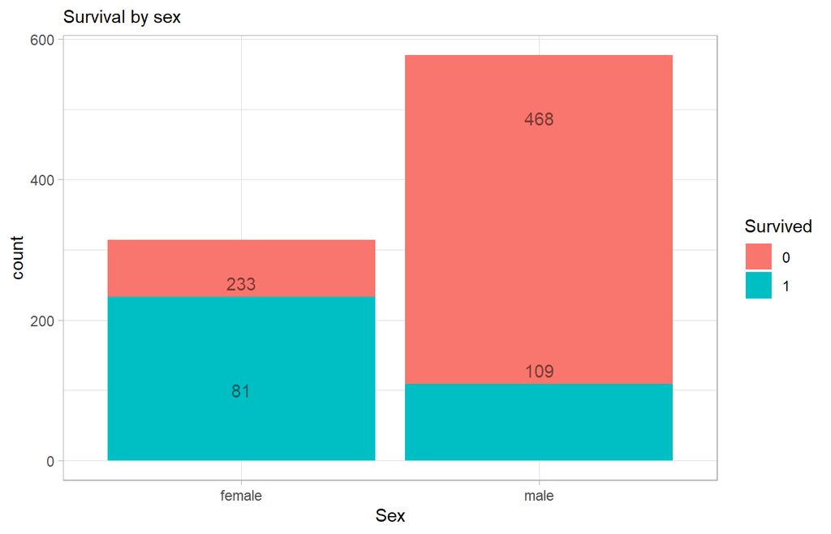

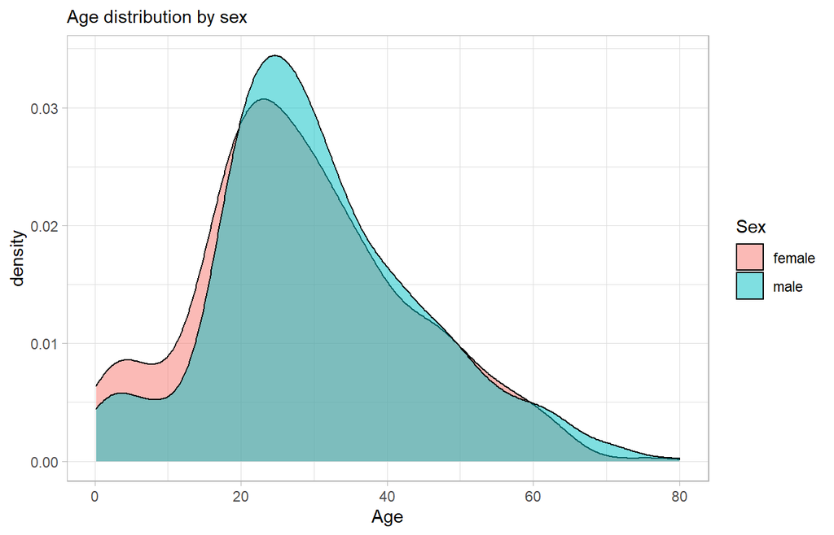

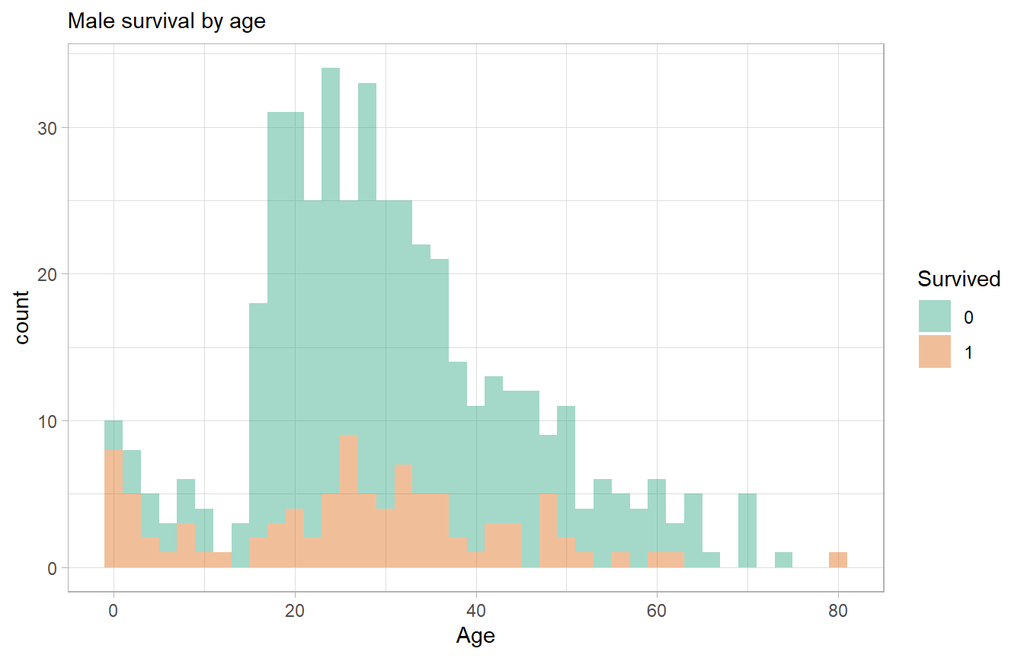

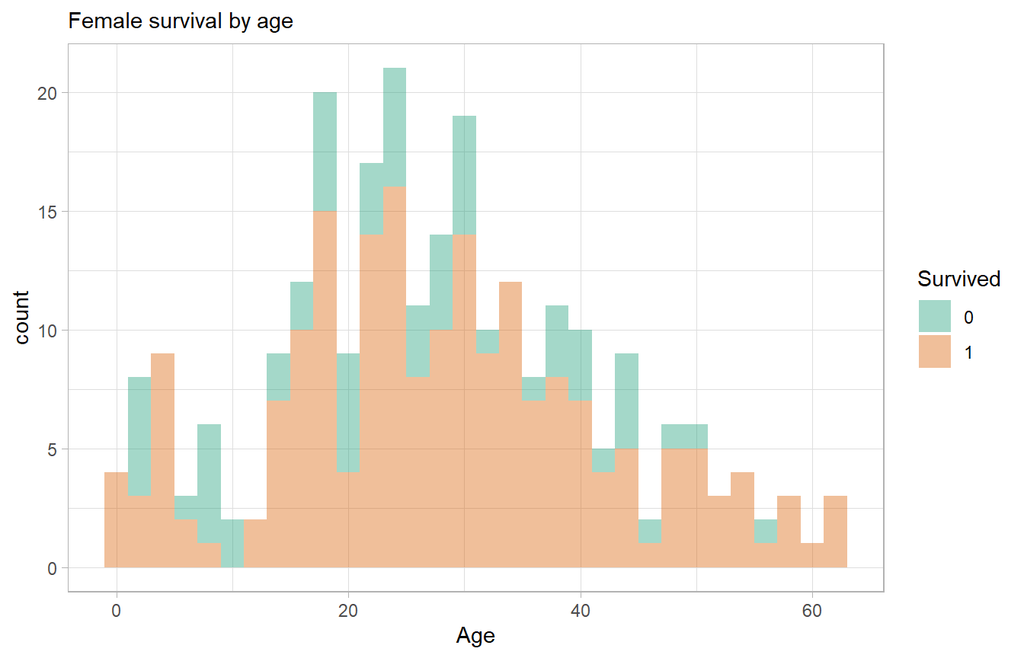

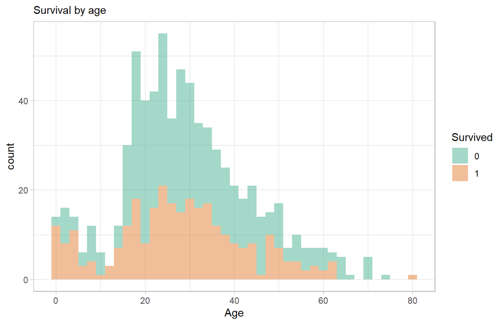

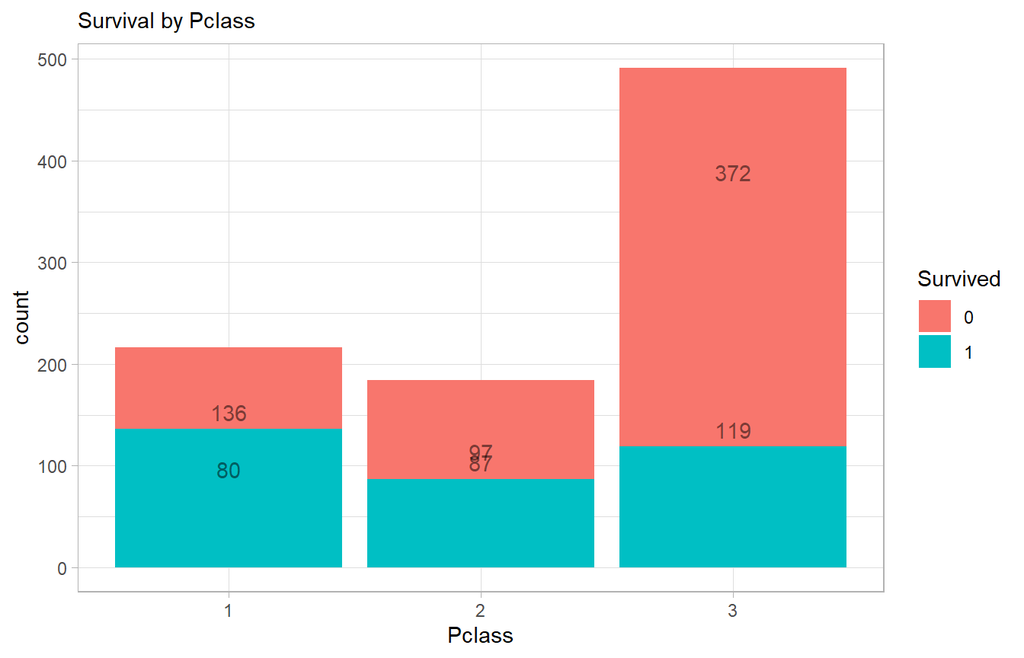

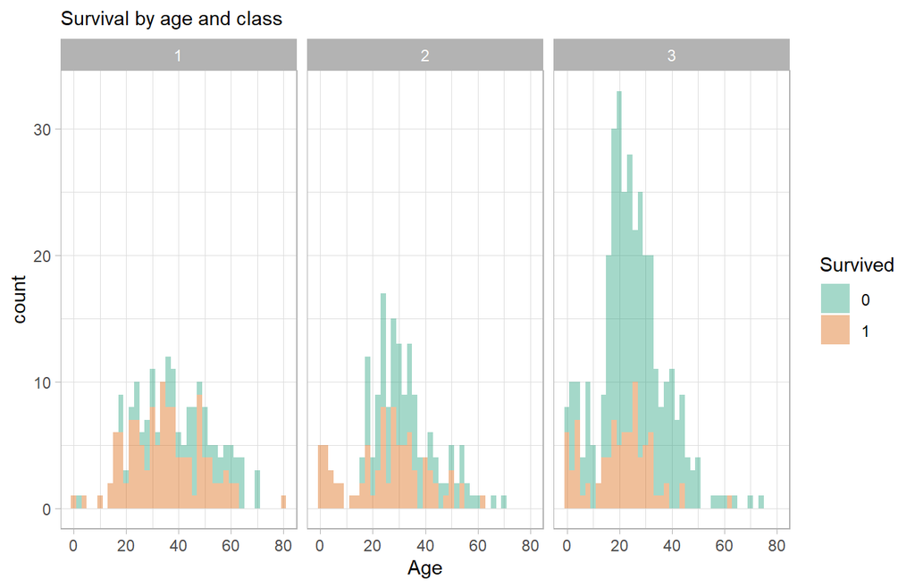

# 2 Feature engineering Part 1/2

## 2.1 Extracting the data from Name variable

```
##
##          Capt Col Don Dona  Dr Jonkheer Lady Major Master Miss Mlle Mme  Mr Mrs
##   female    0   0   0    1   1        0    1     0      0  260    2   1   0 197
##   male      1   4   1    0   7        1    0     2     61    0    0   0 757   0
##
##           Ms Rev Sir the Countess
##   female   2   0   0            1
##   male     0   8   1            0
```

[figure not shown]

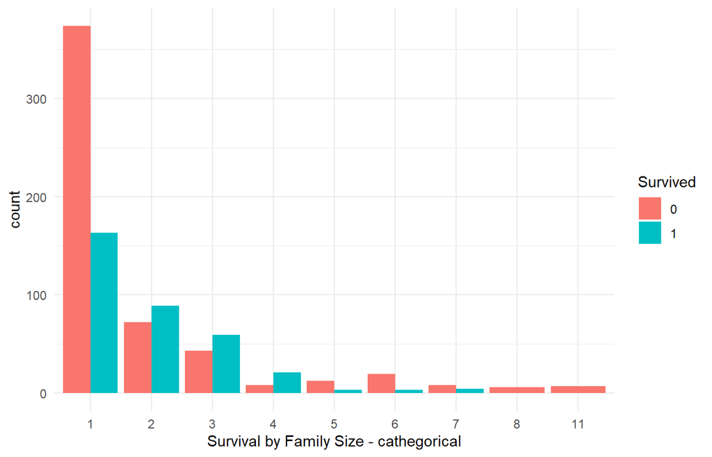

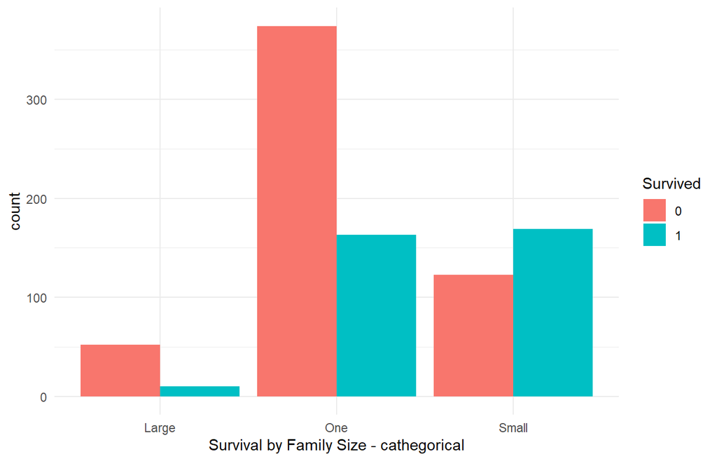

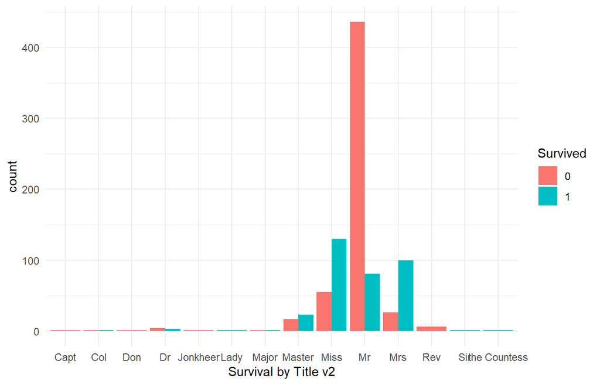

## 2.2 Location - cabin variable

Location onboard - Cabin variable There is a lot of missing info for most people Moreover, some people have more than one cabin assignet to their name - usually the numbers are really close so I will just take the first one or skip the numbers and just take the deck? letter and see if there is any correlation with survival rate.

```r
# Extracting the Deck letter from Cabin variable
tt$Deck <- str_match(tt$Cabin, "[A-Z]")
```

From the future: I saw that this variable seems really significant. Lets see if improving it can influence the results. Checking if info about the cabin is presents has an impact on survival rate - from the experience with some OHSAS systems, knowledge location of people in danger is a significant factor, lets see if this is true:

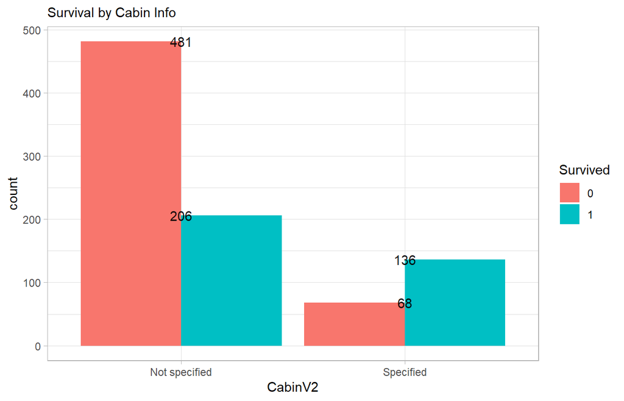

```r
tt <- tt %>%
  mutate(CabinV2 =  factor(case_when(Cabin != "" | is.na(Cabin) ~ "Specified",
                                     TRUE ~ "Not specified")))

ggplot(tt %>% tidyr::drop_na(Survived), aes(x = CabinV2, fill = Survived))+
  geom_bar(stat='count', position='dodge')+
  geom_text(stat='count', aes(label=..count..), alpha = 0.9)+
  labs(subtitle = "Survival by Cabin Info")
```

This could be significant when iterating with the structure of RF model.

# 3 Couping with missing data

## 3.1 Embarked variable

Starting with embark variable, witch is basically the location they started the cruise. Lets see what’s missing from Embarked:

```r
a <- tt %>%
  filter(is.na(Embarked) | Embarked == "")
```

So just two people with PassengerId values 62 and 830 - both are from class 1, both were adults and both paid 80$ for their tickets. Firstly I have to check if the ticket price varies depending on age to know whether to filter the data by age before guessing the Embark location.

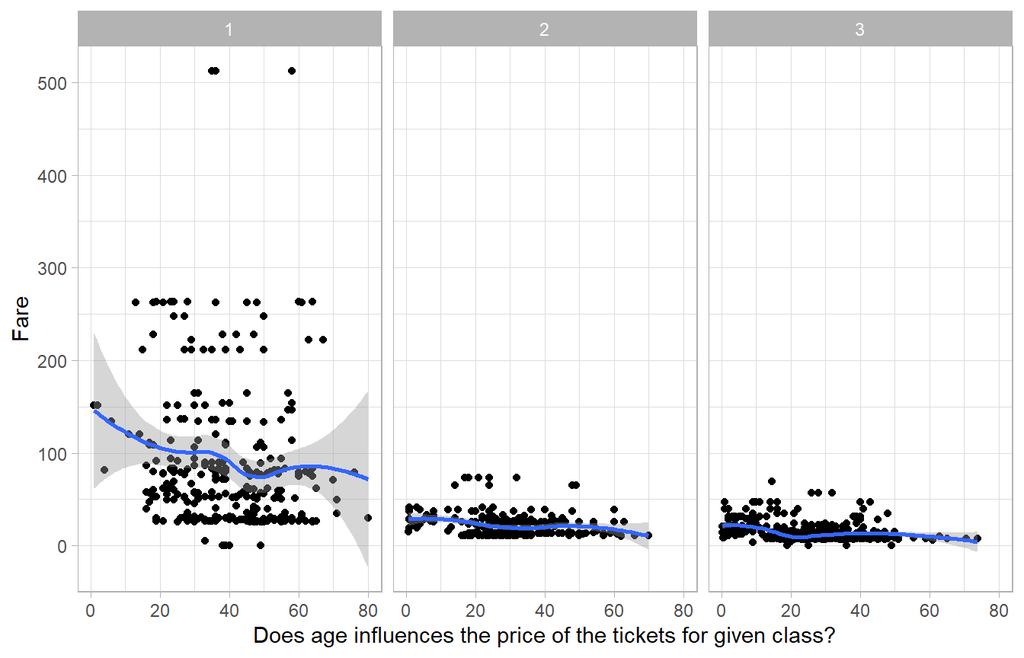

```r
ggplot(tt, aes(x = Age, y = Fare)) +
  geom_point()+
  geom_smooth()+
  facet_wrap(~Pclass)+
  labs(x = "Does age influences the price of the tickets for given class?")
```

The graph results seems counter-intuitive indication higher prices for younger passengers especially for Pclass = 1. Out of curiosity: Lets see if sex influenced the ticket price.

```r
tt %>% group_by(Sex, Pclass) %>%
  summarise(median(Fare, na.rm=T)) # lol it did. shame on them! but we still need the embark location!
```

```
## # A tibble: 6 x 3
## # Groups:   Sex [2]
##   Sex    Pclass `median(Fare, na.rm = T)`
##   <fct>  <fct>                      <dbl>
## 1 female 1                          80.9
## 2 female 2                          23
## 3 female 3                          10.5
## 4 male   1                          49.5
## 5 male   2                          13
## 6 male   3                           7.90
```

```r
# Lets just see the prices Pclass and Embark location for females
tt %>%
  filter(Sex == "female") %>%
  group_by(Pclass, Embarked) %>%
  summarise(Fare_median = median(Fare, na.rm=T),
            Fare_mean = mean(Fare),
            Amount = n())
```

```
## # A tibble: 10 x 5
## # Groups:   Pclass [3]
##    Pclass Embarked Fare_median Fare_mean Amount
##    <fct>  <fct>          <dbl>     <dbl>  <int>
##  1 1      ""             80        80         2
##  2 1      "C"            83.2     119.       71
##  3 1      "Q"            90        90         2
##  4 1      "S"            78.8     101.       69
##  5 2      "C"            27.7      27.0      11
##  6 2      "Q"            12.4      12.4       2
##  7 2      "S"            23        23.0      93
##  8 3      "C"            14.5      13.8      31
##  9 3      "Q"             7.75      9.79     56
## 10 3      "S"            13.8      18.1     129
```

```r
# Lets dig deeper - Family size vs price ticket -
tt %>%
  filter(Sex == "female", Pclass == "1") %>%
  group_by(FamilySizeCat, Embarked) %>%
  summarise(Fare_median = median(Fare, na.rm=T),
            Fare_mean = mean(Fare),
            Amount = n()) %>% data.frame()
```

```
##   FamilySizeCat Embarked Fare_median Fare_mean Amount
## 1         Large        C   262.37500 262.37500      3
## 2         Large        S   263.00000 263.00000      4
## 3           One             80.00000  80.00000      2
## 4           One        C    81.17915 116.87736     30
## 5           One        S    86.50000 103.89834     20
## 6         Small        C    82.66455 109.16228     38
## 7         Small        Q    90.00000  90.00000      2
## 8         Small        S    66.60000  85.41787     45
```

There is clear difference in ticket price between the classes. Without further investigation we can assume that the two women Embarked from port “C”, even though “S” is also a probable option, but its inferior fit.

```r
tt$Embarked[c(62, 830)] <- "C"
```

## 3.2 Fare variable

Lets see other missing data. One person ID 1044 does not have Fare price value:

```r
tt %>%
  filter(is.na(Fare) | Fare == "")
```

```
##   PassengerId Survived Pclass               Name  Sex  Age SibSp Parch Ticket
## 1        1044     <NA>      3 Storey, Mr. Thomas male 60.5     0     0   3701
##   Fare Cabin Embarked Title FamilySize Title2 FamilySizeCat Surname Deck
## 1   NA              S    Mr          1     Mr           One  Storey <NA>
##         CabinV2
## 1 Not specified
```

Lets fit a fare cost based on Embark location, Pclass and sex

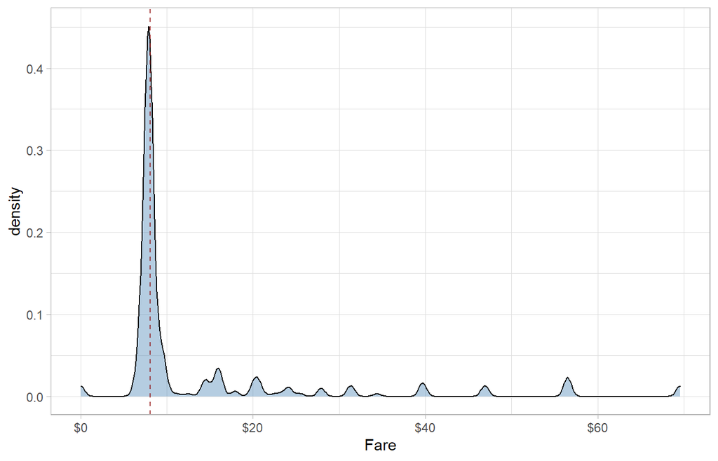

```r
ggplot(tt %>%
         tidyr::drop_na(Survived) %>%
         filter(Pclass == 3 & Embarked == "S" & Sex == "male"),
       aes(x = Fare)) +
  geom_density(fill = 'steelblue', alpha=0.4) +
  geom_vline(aes(xintercept=median(Fare, na.rm=T)),
    colour='darkred', linetype='dashed', alpha = 0.7) +
  scale_x_continuous(labels=dollar_format())
```

```r
# Just filling the missing data with median calculated according to filters below:
tt$Fare[1044] <- tt %>%
  filter(Pclass == 3 & Embarked == "S" & Sex == "male") %>%
  select(Fare) %>%
  summarise(median(Fare, na.rm = T)) %>%
  as.numeric()
```

Make cathegorical variables into factors

```r
tt$PassengerId <- as.factor(tt$PassengerId)
tt$Title <- as.factor(tt$Title)
tt$Title2 <- as.factor(tt$Title2)
tt$FamilySize <- as.factor(tt$FamilySize)
tt$FamilySizeCat <- as.factor(tt$FamilySizeCat)
tt$Deck <- as.factor(tt$Deck)
tt$Survived <- as.factor(tt$Survived)
```

## 3.3 Age/Deck - Predictive imputation with mice

```r
# Set a random seed
set.seed(111)
# Perform mice imputation, excluding certain less-than-useful variables:
mice_mod <- mice(tt[, !names(tt) %in% c('PassengerId','Name','Ticket','Cabin','FamilySize','Surname','Survived')], method='rf')
```

Save the complete output:

```r
mice_output <- complete(mice_mod)
```

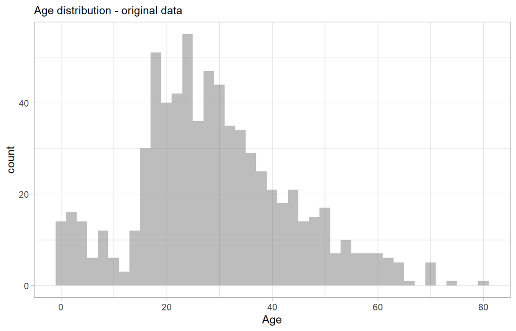

```r
ggplot(tt %>% tidyr::drop_na(Survived), aes(x=Age)) +
  geom_histogram(alpha = 0.4, binwidth = 2)+
  labs(subtitle = "Age distribution - original data")
```

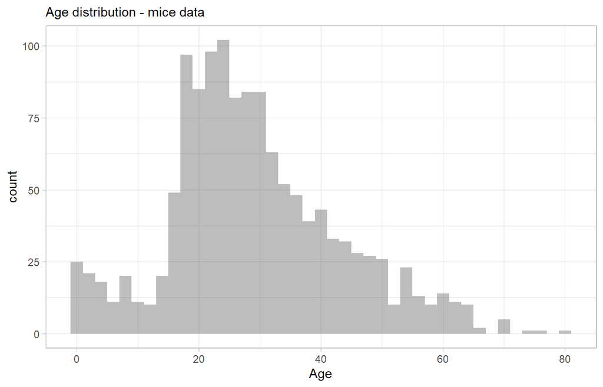

```r
ggplot(mice_output, aes(x=Age)) +
  geom_histogram(alpha = 0.4, binwidth = 2)+
  labs(subtitle = "Age distribution - mice data")
```

Replace the original age data with mice output

```r
tt$Age <- mice_output$Age
tt$Deck <- mice_output$Deck
sum(is.na(tt$Age))
```

```
## [1] 0
```

```r
sum(is.na(tt$Deck))
```

```
## [1] 0
```

# 4 Feature engineering Part 2/2

## 4.1 Adolescence variable

Lets create more variables having complete information and check if there is a connection.

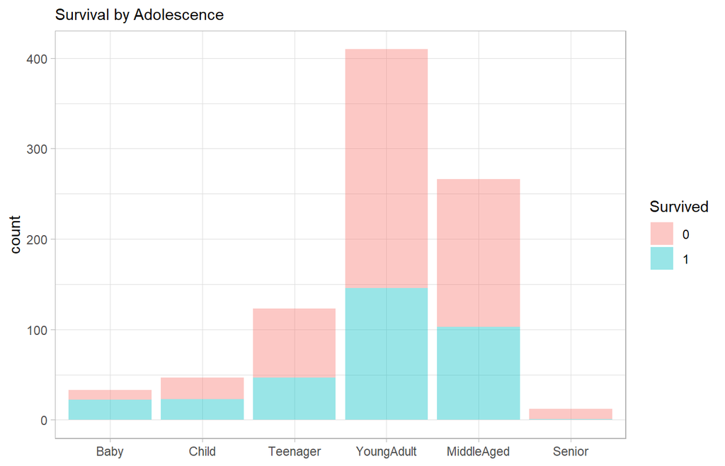

```r
tt <- tt %>%
  mutate(Adolescence = factor(case_when(Age <= 3 ~ "Baby",
                                        Age <= 12 ~ "Child",
                                        Age <= 19 ~ "Teenager",
                                        Age <= 34 ~ "YoungAdult",
                                        Age <= 64 ~ "MiddleAged",
                                        TRUE ~ "Senior"),
                              levels = c("Baby", "Child", "Teenager", "YoungAdult", "MiddleAged", "Senior"),
                              ordered = T))

ggplot(tt %>% tidyr::drop_na(Survived), aes(x=Adolescence, fill = Survived)) +
  geom_bar(alpha = 0.4)+
  labs(subtitle = "Survival by Adolescence",
       x = NULL)
```

I have to admit I am happy with that category.

## 4.2 Motherhood variable

Lets see if mothers are favoured to survive.

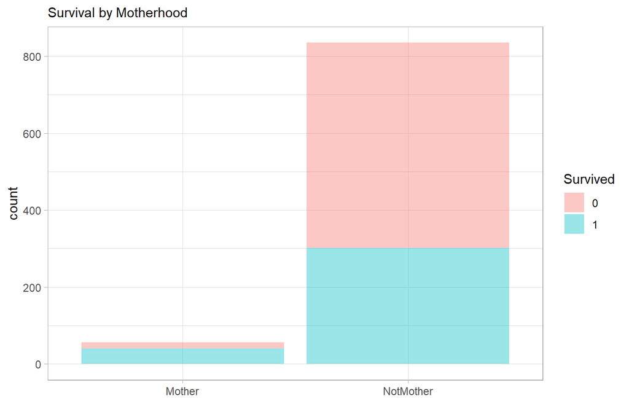

```r
tt <- tt %>%
  mutate(Motherhood = factor(case_when(Age < 18 ~ "NotMother",
                                       Parch == 0 ~ "NotMother",
                                       Sex == "male" ~ "NotMother",
                                       Title == "Miss" ~ "NotMother",
                                       TRUE ~ "Mother")))

ggplot(tt %>% tidyr::drop_na(Survived), aes(x=Motherhood, fill = Survived)) +
  geom_bar(alpha = 0.4)+
  labs(subtitle = "Survival by Motherhood",
       x = NULL)
```

## Surname Frequency

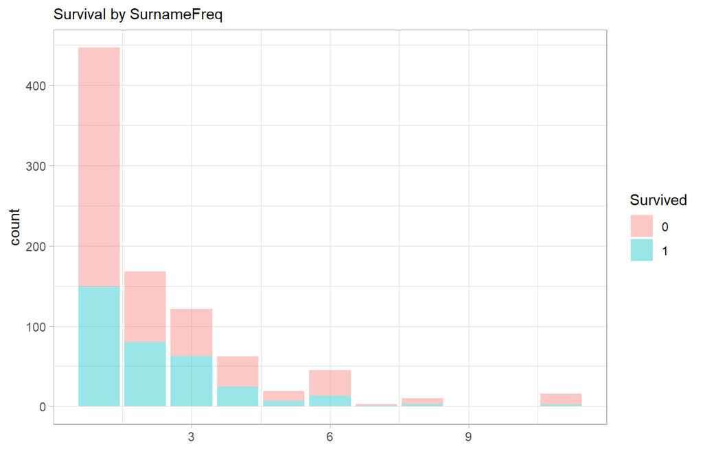

```r
tt <- transform(tt, SurnameFreq = ave(seq(nrow(tt)), Surname, FUN=length))

ggplot(tt %>% tidyr::drop_na(Survived), aes(x=SurnameFreq, fill = Survived)) +
  geom_bar(alpha = 0.4)+
  labs(subtitle = "Survival by SurnameFreq",
       x = NULL)
```

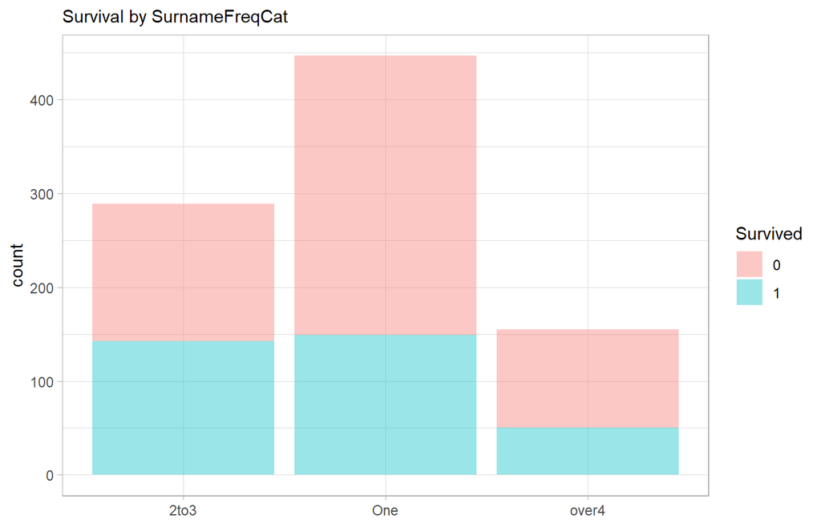

```r
tt <- tt %>% mutate(SurnameFreqCat = factor(case_when(SurnameFreq == 1 ~ "One",
                                               SurnameFreq <= 3 & SurnameFreq > 1 ~ "2to3",
                                               TRUE ~ "over4")))

ggplot(tt %>% tidyr::drop_na(Survived), aes(x=SurnameFreqCat, fill = Survived)) +
  geom_bar(alpha = 0.4)+
  labs(subtitle = "Survival by SurnameFreqCat",
       x = NULL)
```

## 4.3 Final touches

Checking if there is missing data:

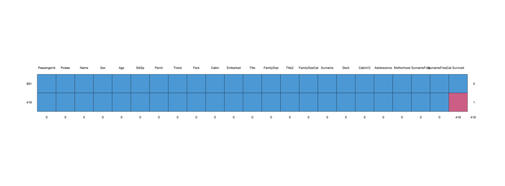

```
##     PassengerId Pclass Name Sex Age SibSp Parch Ticket Fare Cabin Embarked
## 891           1      1    1   1   1     1     1      1    1     1        1
## 418           1      1    1   1   1     1     1      1    1     1        1
##               0      0    0   0   0     0     0      0    0     0        0
##     Title FamilySize Title2 FamilySizeCat Surname Deck CabinV2 Adolescence
## 891     1          1      1             1       1    1       1           1
## 418     1          1      1             1       1    1       1           1
##         0          0      0             0       0    0       0           0
##     Motherhood SurnameFreq SurnameFreqCat Survived
## 891          1           1              1        1   0
## 418          1           1              1        0   1
##              0           0              0      418 418
```

```r
md.pattern(tt)
```

There is no missing data. So now is the time to split the dataset to train and test datasets.

```r
train <- tt[1:891,]
test <- tt[892:1309,]
```

# 5 RandomForest Model

Using randomForest classification algorithm from caret package.

```r
set.seed( seed = 666)

training <- train %>%
  select(Pclass,
         Sex,
         Age,
         Fare,
         Title2,
         FamilySizeCat,
         Adolescence,
         Motherhood,
         Deck,
         Survived)

model_RF <- train(Survived~.,
                  data=training,
                  method="rf",
                  metric="Accuracy",
                  preProcess = "scale",
                  tuneGrid=expand.grid(.mtry=c(2:5)),
                  trControl=trainControl(method="repeatedcv", number=10, repeats=3),
                  ntree = 2000)

print(model_RF)
```

```
## Random Forest
##
## 891 samples
##   9 predictor
##   2 classes: '0', '1'
##
## Pre-processing: scaled (24)
## Resampling: Cross-Validated (10 fold, repeated 3 times)
## Summary of sample sizes: 801, 802, 803, 802, 802, 802, ...
## Resampling results across tuning parameters:
##
##   mtry  Accuracy   Kappa
##   2     0.8219560  0.6143554
##   3     0.8252975  0.6192863
##   4     0.8294175  0.6293471
##   5     0.8342739  0.6402954
##
## Accuracy was used to select the optimal model using the largest value.
## The final value used for the model was mtry = 5.
```

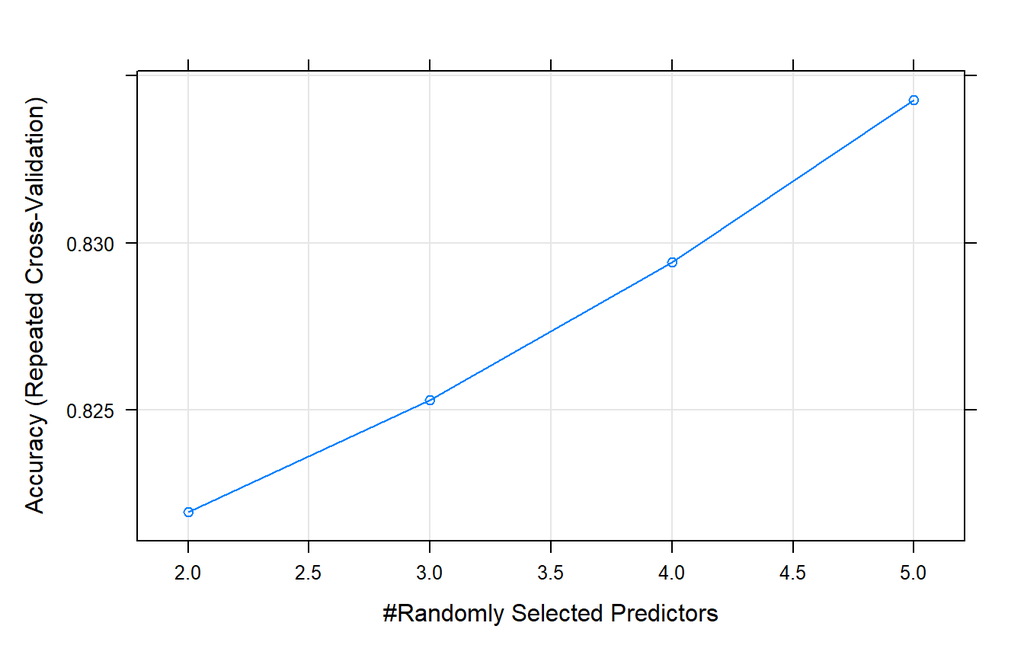

```r
plot(model_RF)
```

## 5.1 Tuning the model

After spending some time picking manually the best combinations of variables I thought that there should be a better automated way of doing this since the calculations are not so robust and searching for optimal parameters should not be done manually. Thus, I decided to do some digging. I found some YT videos and read some articles. After trying some methods I decided to use ‘caret’ package and implement the approach from this articles: https://machinelearningmastery.com/feature-selection-with-the-caret-r-package/ https://machinelearningmastery.com/tune-machine-learning-algorithms-in-r/

### 5.1.1 Variable importance

```r
importance <- varImp(model_RF, scale=FALSE)
# summarize importance
print(importance)
```

```
## rf variable importance
##
##   only 20 most important variables shown (out of 24)
##
##                    Overall
## Fare                58.866
## Sexmale             47.878
## Title2Mr            47.462
## Age                 41.600
## Pclass3             22.019
## Title2Miss          15.133
## Title2Mrs           13.865
## FamilySizeCatSmall  13.684
## Adolescence.L        7.279
## Pclass2              6.648
## DeckE                6.151
## FamilySizeCatOne     5.999
## Adolescence.Q        5.778
## DeckC                5.689
## DeckG                5.132
## DeckF                4.836
## DeckB                4.645
## Adolescence.C        4.538
## DeckD                4.502
## Adolescence^4        4.456
```

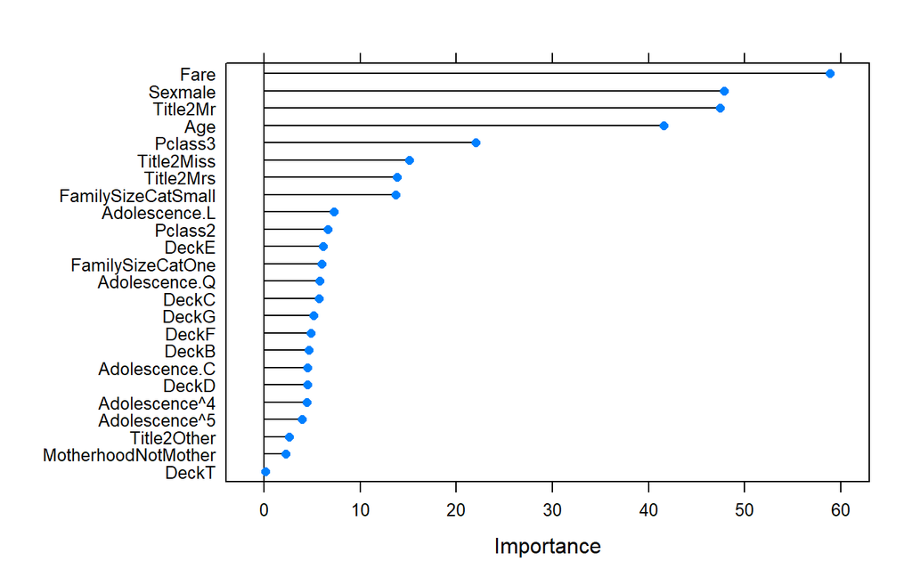

```r
# plot importance
plot(importance)
```

I decided to find the best value for mtry and then the optimal ntree value, while skipping potential interaction effects between the parameters.

### 5.1.2 Grid search

```r
# set.seed(seed = 7)
# # Create model with default parameters
# training <- train %>%
#   select(Pclass, Sex, Age, SibSp, Parch, Fare, Embarked,
#          Title, FamilySizeCat, Adolescence, Motherhood,
#          Deck, FamilySize, CabinV2,
#          Survived)
#
# rf_default <- train(Survived~.,
#                     data=training,
#                     method="rf",
#                     metric="Accuracy",
#                     tuneGrid=expand.grid(.mtry=c(1:10)),
#                     trControl=trainControl(method="repeatedcv", number=10, repeats=3, search="grid"))
# print(rf_default)
# plot(rf_default)
```

### 5.1.3 Number of trees

```r
# set.seed(seed = 666)
#
# training <- train %>%
#   select(Pclass,
#          Sex,
#          Age,
#          Fare,
#          Title,
#          FamilySizeCat,
#          Adolescence,
#          Motherhood,
#          Deck,
#          Survived)
#
# # Manual Search
# modellist <- list()
#
# for (ntree in c(1600, 1650, 1700, 1750, 1800, 1850, 1900, 1950, 2000)) {
#
#   fit <- train(Survived~.,
#                data=training,
#                method="rf",
#                metric="Accuracy",
#                tuneGrid = expand.grid(.mtry=4),
#                ntree = ntree)
#
#   key <- toString(ntree)
#   modellist[[key]] <- fit
# }
#
# # compare results
# results <- resamples(modellist)
# summary(results)
# dotplot(results)
```

## 5.2 Model error

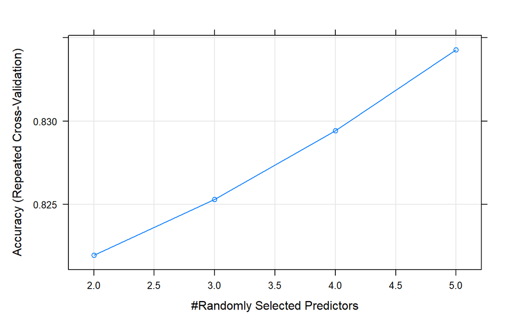

```r
plot(model_RF)
```

```r
model_RF$confusion
```

[output not shown]

# 6 Making prediction

```r
prediction <- predict(model_RF, test)

solution <- data.frame(PassengerID = test$PassengerId, Survived = prediction)
# solution %>% str()

solution <- solution %>%
  mutate(PassengerID = as.integer(PassengerID),
         Survived = as.integer(Survived)-1)

write.csv(solution, file = 'RF_mod_Solution.csv', row.names = F)
```

# 7 XGBoost Model

Since xgboost needs numerical variables I need to convert the data accordingly. For that I am using library(vtreat). I saw that someone on Kaggle managed to create a nice treatment plan to do one-hot-encoding without much hassle, but on different data set. Reference: https://www.kaggle.com/pelkoja/visual-xgboost-tuning-with-caret

```r
xgbtt <- tt %>%
  select(-Name, -Ticket, -Cabin, -Surname, -Survived) %>% # all vars -> xgboost acc: Accuracy/Kappa 0.7922535/0.5606442
  select(-CabinV2, -SurnameFreq, -Title,
         -SibSp, -Parch, -FamilySize)  # vars from best RFmodel but with SurnameCat -> xgboost acc: Accuracy/Kappa 0.8008803  0.5797307
  # select(-SurnameFreqCat) # vars from best RFmodel

xgbtt %>% colnames()
```

```
##  [1] "PassengerId"    "Pclass"         "Sex"            "Age"
##  [5] "Fare"           "Embarked"       "Title2"         "FamilySizeCat"
##  [9] "Deck"           "Adolescence"    "Motherhood"     "SurnameFreqCat"
```

```r
treat_plan <- vtreat::designTreatmentsZ(
  dframe = xgbtt, # training data
  varlist = colnames(xgbtt) %>% .[. != "PassengerId"], # input variables = all training data columns, except id
  codeRestriction = c("clean", "isBAD", "lev"), # derived variables types (drop cat_P)
  verbose = FALSE) # suppress messages

score_frame <- treat_plan$scoreFrame %>%
  select(varName, origName, code)

head(score_frame)
```

```
##            varName origName  code
## 1              Age      Age clean
## 2             Fare     Fare clean
## 3   Pclass_lev_x_1   Pclass   lev
## 4   Pclass_lev_x_2   Pclass   lev
## 5   Pclass_lev_x_3   Pclass   lev
## 6 Sex_lev_x_female      Sex   lev
```

```r
# list of variables without the target variable
# xgbtt$Survived <- as.numeric(-1)
rm(xgb_treated)
xgb_treated <- vtreat::prepare(treat_plan, xgbtt)
```

[figure not shown]

```r
library(corrplot)
cor(xgb_treated, method = c("spearman")) %>% corrplot()
```

Delete highly correlated variables

```r
hc <- findCorrelation(cor(xgb_treated, method = c("spearman")), cutoff=0.65)# %>% sort(.)
reduced_Data = xgb_treated[,-c(hc)]
```

[figure not shown]

```r
cor(reduced_Data, method = c("spearman")) %>% corrplot()
```

```r
xgb_tr <- reduced_Data[1:891,]
xgb_te <- reduced_Data[892:1309,]
```

```r
input_x <- as.matrix(reduced_Data[1:891,])
input_y <- factor(train$Survived)
```

Default hyperparameters

```r
grid_default <- expand.grid(
  nrounds = 100,
  max_depth = 6,
  eta = 0.3,
  gamma = 0,
  colsample_bytree = 1,
  min_child_weight = 1,
  subsample = 1
)

train_control <- caret::trainControl(
  method = "cv",
  verboseIter = F, # if u want training log
  allowParallel = TRUE, # FALSE for reproducible results
)

xgb_base <- caret::train(
  x = input_x,
  y = input_y,
  trControl = train_control,
  tuneGrid = grid_default,
  method = "xgbTree",
  verbose = TRUE
)

print(xgb_base)
```

```
## eXtreme Gradient Boosting
##
## 891 samples
##  28 predictor
##   2 classes: '0', '1'
##
## No pre-processing
## Resampling: Cross-Validated (10 fold)
## Summary of sample sizes: 802, 802, 802, 802, 803, 801, ...
## Resampling results:
##
##   Accuracy   Kappa
##   0.8013557  0.5692949
##
## Tuning parameter 'nrounds' was held constant at a value of 100
## Tuning
##  held constant at a value of 1
## Tuning parameter 'subsample' was held
##  constant at a value of 1
```

## 7.1 Grid Search for Hyperparameters

### 7.1.1 Number of Iterations and the Learning Rate

To get reasonable running time while testing hyperparameter combinations with caret we don’t want to go over 1000. Then, we want to find a good enough learning rate for this number of trees, as for lower learning rates 1000 iterations might not be enough.

Next, as the maximum tree depth is also depending on the number of iterations and the learning rate, we want to experiment with it at this point to narrow down the possible hyperparameters. We’ll also create a helper function to create the visualizations with ggplot2, called tuneplot():

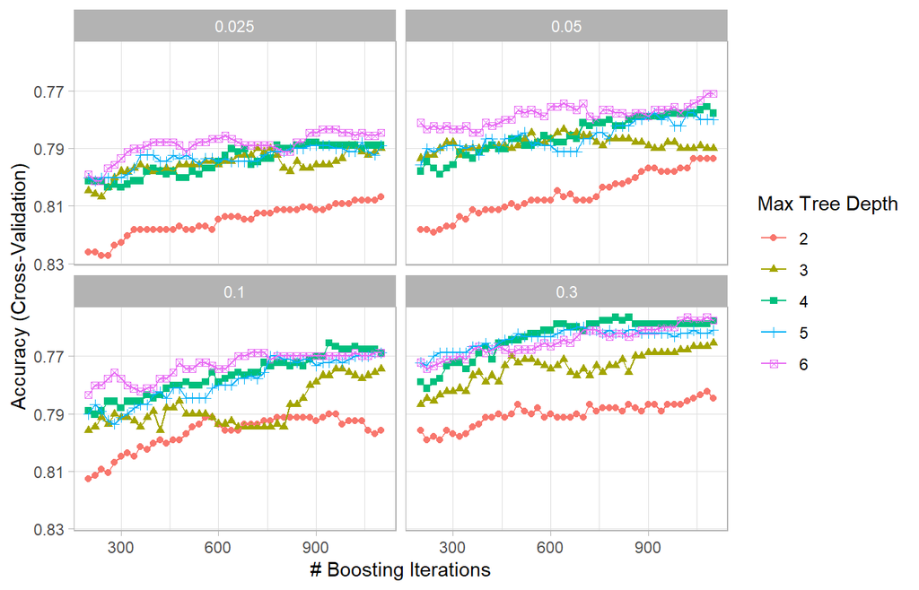

```r
# note to start nrounds from 200, as smaller learning rates result in errors so
# big with lower starting points that they'll mess the scales

nrounds <- 1100

tune_grid <- expand.grid(
  nrounds = seq(from = 200, to = nrounds, by = 20),
  eta = c(0.025, 0.05, 0.1, 0.3),
  max_depth = c(2, 3, 4, 5, 6),
  gamma = 0,
  colsample_bytree = 1,
  min_child_weight = 1,
  subsample = 1
)

tune_control <- caret::trainControl(
  method = "cv", # cross-validation
  number = 3, # with n folds
  #index = createFolds(tr_treated$Id_clean), # fix the folds
  verboseIter = FALSE, # no training log
  allowParallel = TRUE # FALSE for reproducible results
)

xgb_tune <- caret::train(
  x = input_x,
  y = input_y,
  trControl = tune_control,
  tuneGrid = tune_grid,
  method = "xgbTree",
  verbose = TRUE
)

# helper function for the plots
tuneplot <- function(x) {
  ggplot(x) +
    coord_cartesian(ylim = c(max(x$results$Accuracy),
                             min(x$results$Accuracy)))
}

tuneplot(xgb_tune)
```

```r
xgb_tune$bestTune
```

```
##   nrounds max_depth   eta gamma colsample_bytree min_child_weight subsample
## 3     240         2 0.025     0                1                1         1
```

### 7.1.2 Maximum Depth and Minimum Child Weight

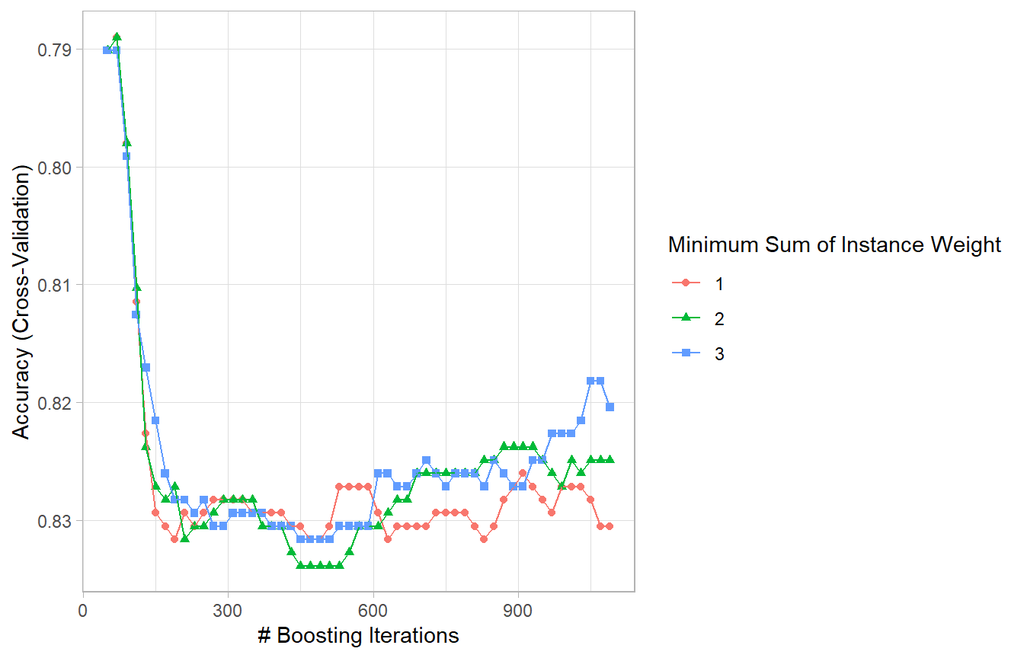

```r
tune_grid2 <- expand.grid(
  nrounds = seq(from = 50, to = nrounds, by = 20),
  eta = xgb_tune$bestTune$eta,
  max_depth = ifelse(xgb_tune$bestTune$max_depth == 2,
    c(xgb_tune$bestTune$max_depth:4),
    xgb_tune$bestTune$max_depth - 1:xgb_tune$bestTune$max_depth + 1),
  gamma = 0,
  colsample_bytree = 1,
  min_child_weight = c(1, 2, 3),
  subsample = 1
)

xgb_tune2 <- caret::train(
  x = input_x,
  y = input_y,
  trControl = tune_control,
  tuneGrid = tune_grid2,
  method = "xgbTree",
  verbose = TRUE
)

tuneplot(xgb_tune2)
```

```r
xgb_tune2$bestTune
```

```
##    nrounds max_depth   eta gamma colsample_bytree min_child_weight subsample
## 74     450         2 0.025     0                1                2         1
```

### 7.1.3 Column and Row Sampling

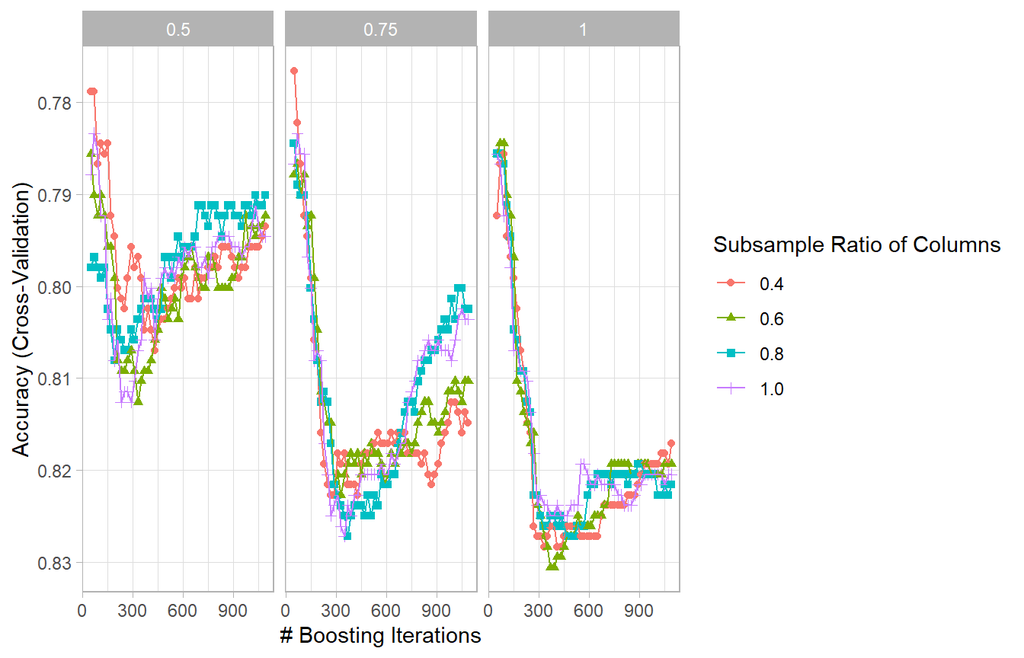

```r
tune_grid3 <- expand.grid(
  nrounds = seq(from = 50, to = nrounds, by = 20),
  eta = xgb_tune$bestTune$eta,
  max_depth = xgb_tune2$bestTune$max_depth,
  gamma = 0,
  colsample_bytree = c(0.4, 0.6, 0.8, 1.0),
  min_child_weight = xgb_tune2$bestTune$min_child_weight,
  subsample = c(0.5, 0.75, 1.0)
)

xgb_tune3 <- caret::train(
  x = input_x,
  y = input_y,
  trControl = tune_control,
  tuneGrid = tune_grid3,
  method = "xgbTree",
  verbose = TRUE
)

tuneplot(xgb_tune3)
```

### Gamma

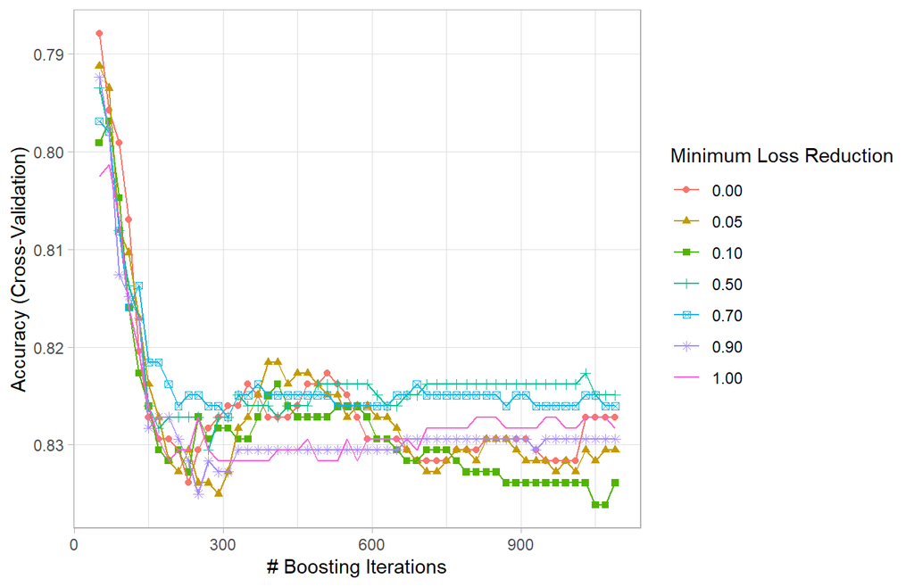

```r
tune_grid4 <- expand.grid(
  nrounds = seq(from = 50, to = nrounds, by = 20),
  eta = xgb_tune$bestTune$eta,
  max_depth = xgb_tune2$bestTune$max_depth,
  gamma = c(0, 0.05, 0.1, 0.5, 0.7, 0.9, 1.0),
  colsample_bytree = xgb_tune3$bestTune$colsample_bytree,
  min_child_weight = xgb_tune2$bestTune$min_child_weight,
  subsample = xgb_tune3$bestTune$subsample
)

xgb_tune4 <- caret::train(
  x = input_x,
  y = input_y,
  trControl = tune_control,
  tuneGrid = tune_grid4,
  method = "xgbTree",
  verbose = TRUE
)

tuneplot(xgb_tune4)
```

### Reducing the Learning Rate

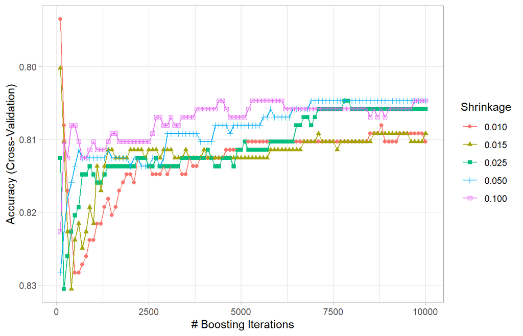

```r
tune_grid5 <- expand.grid(
  nrounds = seq(from = 100, to = 10000, by = 100),
  eta = c(0.01, 0.015, 0.025, 0.05, 0.1),
  max_depth = xgb_tune2$bestTune$max_depth,
  gamma = xgb_tune4$bestTune$gamma,
  colsample_bytree = xgb_tune3$bestTune$colsample_bytree,
  min_child_weight = xgb_tune2$bestTune$min_child_weight,
  subsample = xgb_tune3$bestTune$subsample
)

xgb_tune5 <- caret::train(
  x = input_x,
  y = input_y,
  trControl = tune_control,
  tuneGrid = tune_grid5,
  method = "xgbTree",
  verbose = TRUE
)

tuneplot(xgb_tune5)
```

```r
xgb_tune5$bestTune
```

```
##     nrounds max_depth   eta gamma colsample_bytree min_child_weight subsample
## 202     200         2 0.025   0.1              0.6                2         1
```

## 7.2 Final XGBoost model

```r
final_grid <- expand.grid(
  nrounds = xgb_tune5$bestTune$nrounds,
  eta = xgb_tune5$bestTune$eta,
  max_depth = xgb_tune5$bestTune$max_depth,
  gamma = xgb_tune5$bestTune$gamma,
  colsample_bytree = xgb_tune5$bestTune$colsample_bytree,
  min_child_weight = xgb_tune5$bestTune$min_child_weight,
  subsample = xgb_tune5$bestTune$subsample
)

xgb_model <- caret::train(
  x = input_x,
  y = input_y,
  trControl = train_control,
  tuneGrid = final_grid,
  method = "xgbTree",
  verbose = TRUE
)
```

```r
print(xgb_model)
```

```
## eXtreme Gradient Boosting
##
## 891 samples
##  28 predictor
##   2 classes: '0', '1'
##
## No pre-processing
## Resampling: Cross-Validated (10 fold)
## Summary of sample sizes: 802, 802, 801, 802, 802, 802, ...
## Resampling results:
##
##   Accuracy   Kappa
##   0.8282647  0.6243864
##
## Tuning parameter 'nrounds' was held constant at a value of 200
## Tuning
##  held constant at a value of 2
## Tuning parameter 'subsample' was held
##  constant at a value of 1
```

# 8 Making prediction

```r
prediction <- predict(xgb_model, xgb_te)

solution <- data.frame(PassengerID = test$PassengerId, Survived = prediction)
# solution %>% str()

solution <- solution %>%
  mutate(PassengerID = as.integer(PassengerID),
         Survived = as.integer(Survived)-1)

write.csv(solution, file = 'RF_mod_Solution.csv', row.names = F)
```